# Risk Factor Analysis

## Outcome Variable

**Outcome Variable:** ever_co

## Predictor Variables

**Intervention Variable:** cleanck

**Adjustment Set:**

- arm
- sex
- W_mage
- meducyrs
- feducyrs
- hhwealth_quart
- W_nrooms
- W_nhh
- W_nchldlt5
- trth2o
- impfloor
- delta_meducyrs
- delta_feducyrs
- delta_hhwealth_quart
- delta_W_nrooms
- delta_W_nhh
- delta_W_nchldlt5
- delta_trth2o
- delta_impfloor

## Stratifying Variables

The analysis was stratified on these variable(s):

- agecat
- studyid
- country

## Data Summary

| agecat | studyid | country | cleanck | ever_co | n_cell | n |
| --- | --- | --- | --- | --- | --- | --- |
| 0-24 months | ki0047075b-MAL-ED | PERU | 1 | 0 | 1 | 2 |
| 0-24 months | ki0047075b-MAL-ED | PERU | 1 | 1 | 0 | 2 |
| 0-24 months | ki0047075b-MAL-ED | PERU | 0 | 0 | 1 | 2 |
| 0-24 months | ki0047075b-MAL-ED | PERU | 0 | 1 | 0 | 2 |
| 0-24 months | ki0047075b-MAL-ED | SOUTH AFRICA | 1 | 0 | 1 | 3 |
| 0-24 months | ki0047075b-MAL-ED | SOUTH AFRICA | 1 | 1 | 1 | 3 |
| 0-24 months | ki0047075b-MAL-ED | SOUTH AFRICA | 0 | 0 | 1 | 3 |
| 0-24 months | ki0047075b-MAL-ED | SOUTH AFRICA | 0 | 1 | 0 | 3 |
| 0-24 months | ki1000108-CMC-V-BCS-2002 | INDIA | 1 | 0 | 142 | 373 |
| 0-24 months | ki1000108-CMC-V-BCS-2002 | INDIA | 1 | 1 | 21 | 373 |
| 0-24 months | ki1000108-CMC-V-BCS-2002 | INDIA | 0 | 0 | 145 | 373 |
| 0-24 months | ki1000108-CMC-V-BCS-2002 | INDIA | 0 | 1 | 65 | 373 |
| 0-24 months | ki1000108-IRC | INDIA | 1 | 0 | 198 | 400 |
| 0-24 months | ki1000108-IRC | INDIA | 1 | 1 | 33 | 400 |
| 0-24 months | ki1000108-IRC | INDIA | 0 | 0 | 130 | 400 |
| 0-24 months | ki1000108-IRC | INDIA | 0 | 1 | 39 | 400 |
| 0-24 months | ki1017093b-PROVIDE | BANGLADESH | 1 | 0 | 508 | 700 |
| 0-24 months | ki1017093b-PROVIDE | BANGLADESH | 1 | 1 | 63 | 700 |
| 0-24 months | ki1017093b-PROVIDE | BANGLADESH | 0 | 0 | 102 | 700 |
| 0-24 months | ki1017093b-PROVIDE | BANGLADESH | 0 | 1 | 27 | 700 |
| 0-24 months | ki1017093c-NIH-Crypto | BANGLADESH | 1 | 0 | 329 | 577 |
| 0-24 months | ki1017093c-NIH-Crypto | BANGLADESH | 1 | 1 | 31 | 577 |
| 0-24 months | ki1017093c-NIH-Crypto | BANGLADESH | 0 | 0 | 200 | 577 |
| 0-24 months | ki1017093c-NIH-Crypto | BANGLADESH | 0 | 1 | 17 | 577 |
| 0-24 months | ki1113344-GMS-Nepal | NEPAL | 1 | 0 | 9 | 537 |
| 0-24 months | ki1113344-GMS-Nepal | NEPAL | 1 | 1 | 0 | 537 |
| 0-24 months | ki1113344-GMS-Nepal | NEPAL | 0 | 0 | 354 | 537 |
| 0-24 months | ki1113344-GMS-Nepal | NEPAL | 0 | 1 | 174 | 537 |
| 0-6 months | ki0047075b-MAL-ED | PERU | 1 | 0 | 1 | 2 |
| 0-6 months | ki0047075b-MAL-ED | PERU | 1 | 1 | 0 | 2 |
| 0-6 months | ki0047075b-MAL-ED | PERU | 0 | 0 | 1 | 2 |
| 0-6 months | ki0047075b-MAL-ED | PERU | 0 | 1 | 0 | 2 |
| 0-6 months | ki0047075b-MAL-ED | SOUTH AFRICA | 1 | 0 | 1 | 3 |
| 0-6 months | ki0047075b-MAL-ED | SOUTH AFRICA | 1 | 1 | 1 | 3 |
| 0-6 months | ki0047075b-MAL-ED | SOUTH AFRICA | 0 | 0 | 1 | 3 |
| 0-6 months | ki0047075b-MAL-ED | SOUTH AFRICA | 0 | 1 | 0 | 3 |
| 0-6 months | ki1000108-CMC-V-BCS-2002 | INDIA | 1 | 0 | 156 | 368 |
| 0-6 months | ki1000108-CMC-V-BCS-2002 | INDIA | 1 | 1 | 6 | 368 |
| 0-6 months | ki1000108-CMC-V-BCS-2002 | INDIA | 0 | 0 | 181 | 368 |
| 0-6 months | ki1000108-CMC-V-BCS-2002 | INDIA | 0 | 1 | 25 | 368 |
| 0-6 months | ki1000108-IRC | INDIA | 1 | 0 | 219 | 399 |
| 0-6 months | ki1000108-IRC | INDIA | 1 | 1 | 12 | 399 |
| 0-6 months | ki1000108-IRC | INDIA | 0 | 0 | 156 | 399 |
| 0-6 months | ki1000108-IRC | INDIA | 0 | 1 | 12 | 399 |
| 0-6 months | ki1017093b-PROVIDE | BANGLADESH | 1 | 0 | 549 | 700 |
| 0-6 months | ki1017093b-PROVIDE | BANGLADESH | 1 | 1 | 22 | 700 |
| 0-6 months | ki1017093b-PROVIDE | BANGLADESH | 0 | 0 | 121 | 700 |
| 0-6 months | ki1017093b-PROVIDE | BANGLADESH | 0 | 1 | 8 | 700 |
| 0-6 months | ki1017093c-NIH-Crypto | BANGLADESH | 1 | 0 | 355 | 577 |
| 0-6 months | ki1017093c-NIH-Crypto | BANGLADESH | 1 | 1 | 5 | 577 |
| 0-6 months | ki1017093c-NIH-Crypto | BANGLADESH | 0 | 0 | 210 | 577 |
| 0-6 months | ki1017093c-NIH-Crypto | BANGLADESH | 0 | 1 | 7 | 577 |
| 0-6 months | ki1113344-GMS-Nepal | NEPAL | 1 | 0 | 9 | 537 |
| 0-6 months | ki1113344-GMS-Nepal | NEPAL | 1 | 1 | 0 | 537 |
| 0-6 months | ki1113344-GMS-Nepal | NEPAL | 0 | 0 | 507 | 537 |
| 0-6 months | ki1113344-GMS-Nepal | NEPAL | 0 | 1 | 21 | 537 |
| 6-24 months | ki0047075b-MAL-ED | SOUTH AFRICA | 1 | 0 | 1 | 1 |
| 6-24 months | ki0047075b-MAL-ED | SOUTH AFRICA | 1 | 1 | 0 | 1 |
| 6-24 months | ki0047075b-MAL-ED | SOUTH AFRICA | 0 | 0 | 0 | 1 |
| 6-24 months | ki0047075b-MAL-ED | SOUTH AFRICA | 0 | 1 | 0 | 1 |
| 6-24 months | ki1000108-CMC-V-BCS-2002 | INDIA | 1 | 0 | 147 | 373 |
| 6-24 months | ki1000108-CMC-V-BCS-2002 | INDIA | 1 | 1 | 16 | 373 |
| 6-24 months | ki1000108-CMC-V-BCS-2002 | INDIA | 0 | 0 | 156 | 373 |
| 6-24 months | ki1000108-CMC-V-BCS-2002 | INDIA | 0 | 1 | 54 | 373 |
| 6-24 months | ki1000108-IRC | INDIA | 1 | 0 | 202 | 400 |
| 6-24 months | ki1000108-IRC | INDIA | 1 | 1 | 29 | 400 |
| 6-24 months | ki1000108-IRC | INDIA | 0 | 0 | 137 | 400 |
| 6-24 months | ki1000108-IRC | INDIA | 0 | 1 | 32 | 400 |
| 6-24 months | ki1017093b-PROVIDE | BANGLADESH | 1 | 0 | 456 | 614 |
| 6-24 months | ki1017093b-PROVIDE | BANGLADESH | 1 | 1 | 51 | 614 |
| 6-24 months | ki1017093b-PROVIDE | BANGLADESH | 0 | 0 | 83 | 614 |
| 6-24 months | ki1017093b-PROVIDE | BANGLADESH | 0 | 1 | 24 | 614 |
| 6-24 months | ki1017093c-NIH-Crypto | BANGLADESH | 1 | 0 | 316 | 559 |
| 6-24 months | ki1017093c-NIH-Crypto | BANGLADESH | 1 | 1 | 27 | 559 |
| 6-24 months | ki1017093c-NIH-Crypto | BANGLADESH | 0 | 0 | 200 | 559 |
| 6-24 months | ki1017093c-NIH-Crypto | BANGLADESH | 0 | 1 | 16 | 559 |
| 6-24 months | ki1113344-GMS-Nepal | NEPAL | 1 | 0 | 8 | 529 |
| 6-24 months | ki1113344-GMS-Nepal | NEPAL | 1 | 1 | 0 | 529 |
| 6-24 months | ki1113344-GMS-Nepal | NEPAL | 0 | 0 | 350 | 529 |
| 6-24 months | ki1113344-GMS-Nepal | NEPAL | 0 | 1 | 171 | 529 |

The following strata were considered:

- agecat: 0-24 months, studyid: ki0047075b-MAL-ED, country: PERU
- agecat: 0-24 months, studyid: ki0047075b-MAL-ED, country: SOUTH AFRICA
- agecat: 0-24 months, studyid: ki1000108-CMC-V-BCS-2002, country: INDIA
- agecat: 0-24 months, studyid: ki1000108-IRC, country: INDIA
- agecat: 0-24 months, studyid: ki1017093b-PROVIDE, country: BANGLADESH
- agecat: 0-24 months, studyid: ki1017093c-NIH-Crypto, country: BANGLADESH
- agecat: 0-24 months, studyid: ki1113344-GMS-Nepal, country: NEPAL
- agecat: 0-6 months, studyid: ki0047075b-MAL-ED, country: PERU
- agecat: 0-6 months, studyid: ki0047075b-MAL-ED, country: SOUTH AFRICA
- agecat: 0-6 months, studyid: ki1000108-CMC-V-BCS-2002, country: INDIA
- agecat: 0-6 months, studyid: ki1000108-IRC, country: INDIA
- agecat: 0-6 months, studyid: ki1017093b-PROVIDE, country: BANGLADESH
- agecat: 0-6 months, studyid: ki1017093c-NIH-Crypto, country: BANGLADESH
- agecat: 0-6 months, studyid: ki1113344-GMS-Nepal, country: NEPAL
- agecat: 6-24 months, studyid: ki0047075b-MAL-ED, country: SOUTH AFRICA
- agecat: 6-24 months, studyid: ki1000108-CMC-V-BCS-2002, country: INDIA
- agecat: 6-24 months, studyid: ki1000108-IRC, country: INDIA
- agecat: 6-24 months, studyid: ki1017093b-PROVIDE, country: BANGLADESH
- agecat: 6-24 months, studyid: ki1017093c-NIH-Crypto, country: BANGLADESH
- agecat: 6-24 months, studyid: ki1113344-GMS-Nepal, country: NEPAL

### Dropped Strata

- agecat: 0-24 months, studyid: ki0047075b-MAL-ED, country: PERU
- agecat: 0-24 months, studyid: ki0047075b-MAL-ED, country: SOUTH AFRICA
- agecat: 0-24 months, studyid: ki1113344-GMS-Nepal, country: NEPAL
- agecat: 0-6 months, studyid: ki0047075b-MAL-ED, country: PERU
- agecat: 0-6 months, studyid: ki0047075b-MAL-ED, country: SOUTH AFRICA
- agecat: 0-6 months, studyid: ki1113344-GMS-Nepal, country: NEPAL
- agecat: 6-24 months, studyid: ki0047075b-MAL-ED, country: SOUTH AFRICA
- agecat: 6-24 months, studyid: ki1113344-GMS-Nepal, country: NEPAL

## Methods Detail

We’re interested in the causal parameters $E[Y_a]$ for all values of $a \in \mathcal{A}$. These parameters represent the mean outcome if, possibly contrary to fact, we intervened to set all units to have $A=a$. Under the randomization and positivity assumptions, these are identified by the statistical parameters $\psi_a=E_W[E_{Y|A,W}(Y|A=a,W)]$. In addition, we’re interested in the mean of $Y$, $E[Y]$ under no intervention (the observed mean). We will estimate these parameters by using SuperLearner to fit the relevant likelihood factors – $E_{Y|A,W}(Y|A=a,W)$ and $p(A=a|W)$, and then updating our likelihood fit using a joint TMLE.

For unadjusted analyses ($W=\{\}$), initial likelihoods were estimated using Lrnr_glm to estimate the simple $E(Y|A)$ and Lrnr_mean to estimate $p(A)$. For adjusted analyses, a small library containing Lrnr_glmnet, Lrnr_xgboost, and Lrnr_mean was used.

Having estimated these parameters, we will then use the delta method to estimate relative risks and attributable risks relative to a prespecified baseline level of $A$.

# Results Detail

## Results Plots

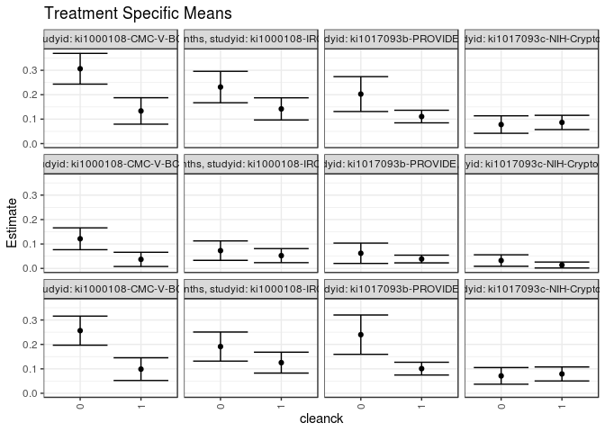

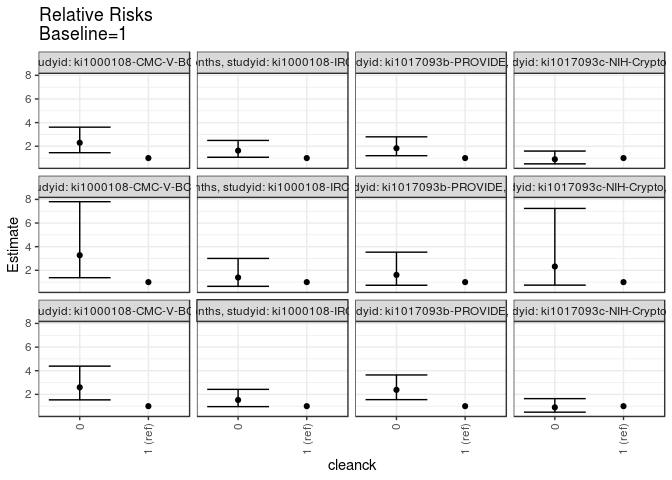

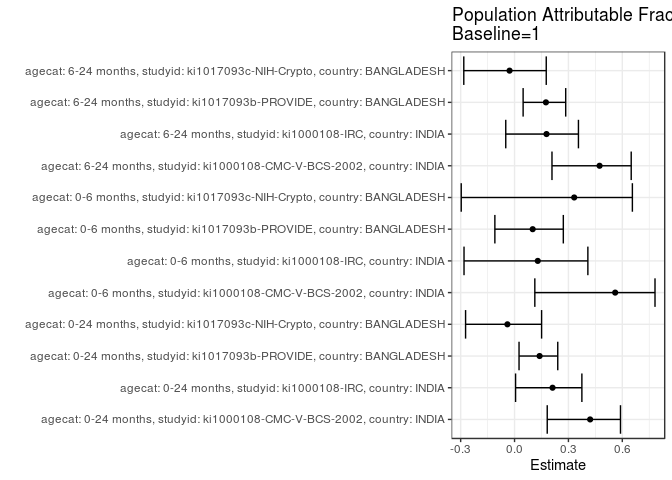

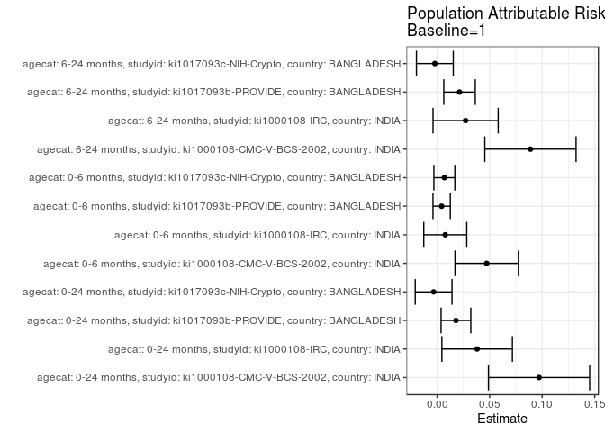

## Results Table

### Parameter: TSM

| agecat | studyid | country | intervention_level | baseline_level | estimate | ci_lower | ci_upper |
| --- | --- | --- | --- | --- | --- | --- | --- |
| 0-24 months | ki1000108-CMC-V-BCS-2002 | INDIA | 1 | NA | 0.1335358 | 0.0794927 | 0.1875789 |
| 0-24 months | ki1000108-CMC-V-BCS-2002 | INDIA | 0 | NA | 0.3062950 | 0.2433379 | 0.3692520 |
| 0-24 months | ki1000108-IRC | INDIA | 1 | NA | 0.1419024 | 0.0966199 | 0.1871850 |
| 0-24 months | ki1000108-IRC | INDIA | 0 | NA | 0.2314115 | 0.1670776 | 0.2957454 |
| 0-24 months | ki1017093b-PROVIDE | BANGLADESH | 1 | NA | 0.1106306 | 0.0848438 | 0.1364175 |
| 0-24 months | ki1017093b-PROVIDE | BANGLADESH | 0 | NA | 0.2026078 | 0.1312591 | 0.2739565 |
| 0-24 months | ki1017093c-NIH-Crypto | BANGLADESH | 1 | NA | 0.0864911 | 0.0573455 | 0.1156367 |
| 0-24 months | ki1017093c-NIH-Crypto | BANGLADESH | 0 | NA | 0.0778650 | 0.0421426 | 0.1135874 |
| 0-6 months | ki1000108-CMC-V-BCS-2002 | INDIA | 1 | NA | 0.0370370 | 0.0079162 | 0.0661579 |
| 0-6 months | ki1000108-CMC-V-BCS-2002 | INDIA | 0 | NA | 0.1213592 | 0.0767066 | 0.1660119 |
| 0-6 months | ki1000108-IRC | INDIA | 1 | NA | 0.0523752 | 0.0236341 | 0.0811163 |
| 0-6 months | ki1000108-IRC | INDIA | 0 | NA | 0.0728133 | 0.0330792 | 0.1125475 |
| 0-6 months | ki1017093b-PROVIDE | BANGLADESH | 1 | NA | 0.0385289 | 0.0227309 | 0.0543269 |
| 0-6 months | ki1017093b-PROVIDE | BANGLADESH | 0 | NA | 0.0620155 | 0.0203658 | 0.1036652 |
| 0-6 months | ki1017093c-NIH-Crypto | BANGLADESH | 1 | NA | 0.0138889 | 0.0017893 | 0.0259885 |
| 0-6 months | ki1017093c-NIH-Crypto | BANGLADESH | 0 | NA | 0.0322581 | 0.0087296 | 0.0557865 |
| 6-24 months | ki1000108-CMC-V-BCS-2002 | INDIA | 1 | NA | 0.0988344 | 0.0523726 | 0.1452961 |
| 6-24 months | ki1000108-CMC-V-BCS-2002 | INDIA | 0 | NA | 0.2563450 | 0.1967894 | 0.3159007 |
| 6-24 months | ki1000108-IRC | INDIA | 1 | NA | 0.1253624 | 0.0825999 | 0.1681249 |
| 6-24 months | ki1000108-IRC | INDIA | 0 | NA | 0.1911776 | 0.1317103 | 0.2506449 |
| 6-24 months | ki1017093b-PROVIDE | BANGLADESH | 1 | NA | 0.1008020 | 0.0746188 | 0.1269852 |
| 6-24 months | ki1017093b-PROVIDE | BANGLADESH | 0 | NA | 0.2398234 | 0.1593186 | 0.3203281 |
| 6-24 months | ki1017093c-NIH-Crypto | BANGLADESH | 1 | NA | 0.0790552 | 0.0504055 | 0.1077049 |
| 6-24 months | ki1017093c-NIH-Crypto | BANGLADESH | 0 | NA | 0.0711708 | 0.0371523 | 0.1051894 |

### Parameter: E(Y)

| agecat | studyid | country | intervention_level | baseline_level | estimate | ci_lower | ci_upper |
| --- | --- | --- | --- | --- | --- | --- | --- |
| 0-24 months | ki1000108-CMC-V-BCS-2002 | INDIA | NA | NA | 0.2305630 | 0.1877616 | 0.2733644 |
| 0-24 months | ki1000108-IRC | INDIA | NA | NA | 0.1800000 | 0.1423032 | 0.2176968 |
| 0-24 months | ki1017093b-PROVIDE | BANGLADESH | NA | NA | 0.1285714 | 0.1037574 | 0.1533855 |
| 0-24 months | ki1017093c-NIH-Crypto | BANGLADESH | NA | NA | 0.0831889 | 0.0606356 | 0.1057422 |
| 0-6 months | ki1000108-CMC-V-BCS-2002 | INDIA | NA | NA | 0.0842391 | 0.0558231 | 0.1126551 |
| 0-6 months | ki1000108-IRC | INDIA | NA | NA | 0.0601504 | 0.0367913 | 0.0835094 |
| 0-6 months | ki1017093b-PROVIDE | BANGLADESH | NA | NA | 0.0428571 | 0.0278427 | 0.0578716 |
| 0-6 months | ki1017093c-NIH-Crypto | BANGLADESH | NA | NA | 0.0207972 | 0.0091432 | 0.0324513 |
| 6-24 months | ki1000108-CMC-V-BCS-2002 | INDIA | NA | NA | 0.1876676 | 0.1479906 | 0.2273445 |
| 6-24 months | ki1000108-IRC | INDIA | NA | NA | 0.1525000 | 0.1172250 | 0.1877750 |
| 6-24 months | ki1017093b-PROVIDE | BANGLADESH | NA | NA | 0.1221498 | 0.0962275 | 0.1480722 |
| 6-24 months | ki1017093c-NIH-Crypto | BANGLADESH | NA | NA | 0.0769231 | 0.0548136 | 0.0990325 |

### Parameter: RR

| agecat | studyid | country | intervention_level | baseline_level | estimate | ci_lower | ci_upper |
| --- | --- | --- | --- | --- | --- | --- | --- |
| 0-24 months | ki1000108-CMC-V-BCS-2002 | INDIA | 1 | 1 | 1.0000000 | 1.0000000 | 1.000000 |
| 0-24 months | ki1000108-CMC-V-BCS-2002 | INDIA | 0 | 1 | 2.2937294 | 1.4559578 | 3.613563 |
| 0-24 months | ki1000108-IRC | INDIA | 1 | 1 | 1.0000000 | 1.0000000 | 1.000000 |
| 0-24 months | ki1000108-IRC | INDIA | 0 | 1 | 1.6307788 | 1.0677492 | 2.490697 |
| 0-24 months | ki1017093b-PROVIDE | BANGLADESH | 1 | 1 | 1.0000000 | 1.0000000 | 1.000000 |
| 0-24 months | ki1017093b-PROVIDE | BANGLADESH | 0 | 1 | 1.8313893 | 1.1994934 | 2.796169 |
| 0-24 months | ki1017093c-NIH-Crypto | BANGLADESH | 1 | 1 | 1.0000000 | 1.0000000 | 1.000000 |
| 0-24 months | ki1017093c-NIH-Crypto | BANGLADESH | 0 | 1 | 0.9002659 | 0.5088126 | 1.592883 |
| 0-6 months | ki1000108-CMC-V-BCS-2002 | INDIA | 1 | 1 | 1.0000000 | 1.0000000 | 1.000000 |
| 0-6 months | ki1000108-CMC-V-BCS-2002 | INDIA | 0 | 1 | 3.2766990 | 1.3753959 | 7.806302 |
| 0-6 months | ki1000108-IRC | INDIA | 1 | 1 | 1.0000000 | 1.0000000 | 1.000000 |
| 0-6 months | ki1000108-IRC | INDIA | 0 | 1 | 1.3902250 | 0.6430711 | 3.005462 |
| 0-6 months | ki1017093b-PROVIDE | BANGLADESH | 1 | 1 | 1.0000000 | 1.0000000 | 1.000000 |
| 0-6 months | ki1017093b-PROVIDE | BANGLADESH | 0 | 1 | 1.6095842 | 0.7327878 | 3.535487 |
| 0-6 months | ki1017093c-NIH-Crypto | BANGLADESH | 1 | 1 | 1.0000000 | 1.0000000 | 1.000000 |
| 0-6 months | ki1017093c-NIH-Crypto | BANGLADESH | 0 | 1 | 2.3225806 | 0.7456384 | 7.234581 |
| 6-24 months | ki1000108-CMC-V-BCS-2002 | INDIA | 1 | 1 | 1.0000000 | 1.0000000 | 1.000000 |
| 6-24 months | ki1000108-CMC-V-BCS-2002 | INDIA | 0 | 1 | 2.5936830 | 1.5332461 | 4.387548 |
| 6-24 months | ki1000108-IRC | INDIA | 1 | 1 | 1.0000000 | 1.0000000 | 1.000000 |
| 6-24 months | ki1000108-IRC | INDIA | 0 | 1 | 1.5249993 | 0.9605571 | 2.421119 |
| 6-24 months | ki1017093b-PROVIDE | BANGLADESH | 1 | 1 | 1.0000000 | 1.0000000 | 1.000000 |
| 6-24 months | ki1017093b-PROVIDE | BANGLADESH | 0 | 1 | 2.3791529 | 1.5541996 | 3.641983 |
| 6-24 months | ki1017093c-NIH-Crypto | BANGLADESH | 1 | 1 | 1.0000000 | 1.0000000 | 1.000000 |
| 6-24 months | ki1017093c-NIH-Crypto | BANGLADESH | 0 | 1 | 0.9002676 | 0.4943761 | 1.639403 |

### Parameter: PAR

| agecat | studyid | country | intervention_level | baseline_level | estimate | ci_lower | ci_upper |
| --- | --- | --- | --- | --- | --- | --- | --- |
| 0-24 months | ki1000108-CMC-V-BCS-2002 | INDIA | 1 | NA | 0.0970272 | 0.0488789 | 0.1451755 |
| 0-24 months | ki1000108-IRC | INDIA | 1 | NA | 0.0380976 | 0.0045446 | 0.0716505 |
| 0-24 months | ki1017093b-PROVIDE | BANGLADESH | 1 | NA | 0.0179408 | 0.0037945 | 0.0320871 |
| 0-24 months | ki1017093c-NIH-Crypto | BANGLADESH | 1 | NA | -0.0033022 | -0.0208046 | 0.0142002 |
| 0-6 months | ki1000108-CMC-V-BCS-2002 | INDIA | 1 | NA | 0.0472021 | 0.0170547 | 0.0773495 |
| 0-6 months | ki1000108-IRC | INDIA | 1 | NA | 0.0077752 | -0.0126701 | 0.0282204 |
| 0-6 months | ki1017093b-PROVIDE | BANGLADESH | 1 | NA | 0.0043282 | -0.0039085 | 0.0125650 |
| 0-6 months | ki1017093c-NIH-Crypto | BANGLADESH | 1 | NA | 0.0069083 | -0.0030683 | 0.0168850 |
| 6-24 months | ki1000108-CMC-V-BCS-2002 | INDIA | 1 | NA | 0.0888332 | 0.0454233 | 0.1322431 |
| 6-24 months | ki1000108-IRC | INDIA | 1 | NA | 0.0271376 | -0.0038696 | 0.0581448 |
| 6-24 months | ki1017093b-PROVIDE | BANGLADESH | 1 | NA | 0.0213478 | 0.0063636 | 0.0363321 |
| 6-24 months | ki1017093c-NIH-Crypto | BANGLADESH | 1 | NA | -0.0021321 | -0.0196577 | 0.0153935 |

### Parameter: PAF

| agecat | studyid | country | intervention_level | baseline_level | estimate | ci_lower | ci_upper |
| --- | --- | --- | --- | --- | --- | --- | --- |
| 0-24 months | ki1000108-CMC-V-BCS-2002 | INDIA | 1 | NA | 0.4208273 | 0.1820262 | 0.5899123 |
| 0-24 months | ki1000108-IRC | INDIA | 1 | NA | 0.2116531 | 0.0057371 | 0.3749230 |
| 0-24 months | ki1017093b-PROVIDE | BANGLADESH | 1 | NA | 0.1395394 | 0.0250294 | 0.2406002 |
| 0-24 months | ki1017093c-NIH-Crypto | BANGLADESH | 1 | NA | -0.0396953 | -0.2726492 | 0.1506172 |
| 0-6 months | ki1000108-CMC-V-BCS-2002 | INDIA | 1 | NA | 0.5603345 | 0.1129210 | 0.7820874 |
| 0-6 months | ki1000108-IRC | INDIA | 1 | NA | 0.1292623 | -0.2813025 | 0.4082708 |
| 0-6 months | ki1017093b-PROVIDE | BANGLADESH | 1 | NA | 0.1009924 | -0.1095560 | 0.2715873 |
| 0-6 months | ki1017093c-NIH-Crypto | BANGLADESH | 1 | NA | 0.3321759 | -0.2968904 | 0.6561089 |
| 6-24 months | ki1000108-CMC-V-BCS-2002 | INDIA | 1 | NA | 0.4733540 | 0.2084490 | 0.6496043 |
| 6-24 months | ki1000108-IRC | INDIA | 1 | NA | 0.1779513 | -0.0489553 | 0.3557742 |
| 6-24 months | ki1017093b-PROVIDE | BANGLADESH | 1 | NA | 0.1747676 | 0.0477724 | 0.2848258 |
| 6-24 months | ki1017093c-NIH-Crypto | BANGLADESH | 1 | NA | -0.0277173 | -0.2826344 | 0.1765363 |